# thompson-ryan-ADA-homework-3

KRT

4/23/2020

# Challenge 1

## Uploading Kamilar and Cooper.

```r
## Challenge 1

f <-"https://raw.githubusercontent.com/difiore/ADA-datasets/master/KamilarAndCooperData.csv"
d <- read.csv(f)
head(d)
```

```
##               Scientific_Name          Family          Genus      Species
## 1 Allenopithecus_nigroviridis Cercopithecidae Allenopithecus nigroviridis
## 2         Allocebus_trichotis Cercopithecidae      Allocebus    trichotis
## 3           Alouatta_belzebul        Atelidae       Alouatta     belzebul
## 4             Alouatta_caraya        Atelidae       Alouatta       caraya
## 5            Alouatta_guariba        Atelidae       Alouatta      guariba
## 6           Alouatta_palliata        Atelidae       Alouatta     palliata
##   Brain_Size_Species_Mean Brain_Size_Female_Mean   Brain_size_Ref
## 1                   58.02                  53.70 Isler et al 2008
## 2                      NA                     NA
## 3                   52.84                  51.19 Isler et al 2008
## 4                   52.63                  47.80 Isler et al 2008
## 5                   51.70                  49.08 Isler et al 2008
## 6                   49.88                  48.04 Isler et al 2008
##   Body_mass_male_mean Body_mass_female_mean Mass_Dimorphism
```

[output cut: 62 more lines]

## Creating simple linear regression model for MaxLongevity_m and Brain_Size_Species_Mean.

```r
d <- d %>%  mutate(
  log_MaxLongevity_m = log(MaxLongevity_m),
  log_Brain_Size_Species_Mean = log(Brain_Size_Species_Mean)
)

a <- lm(MaxLongevity_m ~ Brain_Size_Species_Mean, data = d)
b <- lm(log_MaxLongevity_m ~ log_Brain_Size_Species_Mean, data = d)

tidy(a)
```

```
## # A tibble: 2 x 5
##   term                    estimate std.error statistic  p.value
##   <chr>                      <dbl>     <dbl>     <dbl>    <dbl>
## 1 (Intercept)               249.      11.1        22.4 8.91e-46
## 2 Brain_Size_Species_Mean     1.22     0.110      11.1 2.69e-20
```

```r
summary(a)
```

```
##
## Call:
## lm(formula = MaxLongevity_m ~ Brain_Size_Species_Mean, data = d)
##
## Residuals:
##     Min      1Q  Median      3Q     Max
## -198.27  -61.92  -17.78   56.16  331.36
##
## Coefficients:
##                         Estimate Std. Error t value Pr(>|t|)
## (Intercept)             248.9523    11.1111   22.41   <2e-16 ***
## Brain_Size_Species_Mean   1.2180     0.1101   11.06   <2e-16 ***
## ---
## Signif. codes:  0 '***' 0.001 '**' 0.01 '*' 0.05 '.' 0.1 ' ' 1
##
## Residual standard error: 90.91 on 126 degrees of freedom
##   (85 observations deleted due to missingness)
## Multiple R-squared:  0.4928, Adjusted R-squared:  0.4887
## F-statistic: 122.4 on 1 and 126 DF,  p-value: < 2.2e-16
```

```r
tidy(b)
```

```
## # A tibble: 2 x 5
##   term                        estimate std.error statistic   p.value
##   <chr>                          <dbl>     <dbl>     <dbl>     <dbl>
## 1 (Intercept)                    4.88     0.0691      70.6 3.32e-103
## 2 log_Brain_Size_Species_Mean    0.234    0.0178      13.1 2.17e- 25
```

```r
summary(b)
```

```
##
## Call:
## lm(formula = log_MaxLongevity_m ~ log_Brain_Size_Species_Mean,
##     data = d)
##
## Residuals:
##     Min      1Q  Median      3Q     Max
## -0.6955 -0.1750 -0.0097  0.1788  0.6084
##
## Coefficients:
##                             Estimate Std. Error t value Pr(>|t|)
## (Intercept)                  4.87895    0.06907   70.63   <2e-16 ***
## log_Brain_Size_Species_Mean  0.23415    0.01781   13.15   <2e-16 ***
## ---
## Signif. codes:  0 '***' 0.001 '**' 0.01 '*' 0.05 '.' 0.1 ' ' 1
##
## Residual standard error: 0.2485 on 126 degrees of freedom
##   (85 observations deleted due to missingness)
## Multiple R-squared:  0.5784, Adjusted R-squared:  0.5751
## F-statistic: 172.9 on 1 and 126 DF,  p-value: < 2.2e-16
```

## Scatterplots with superimposed lines, fitted model equation included.

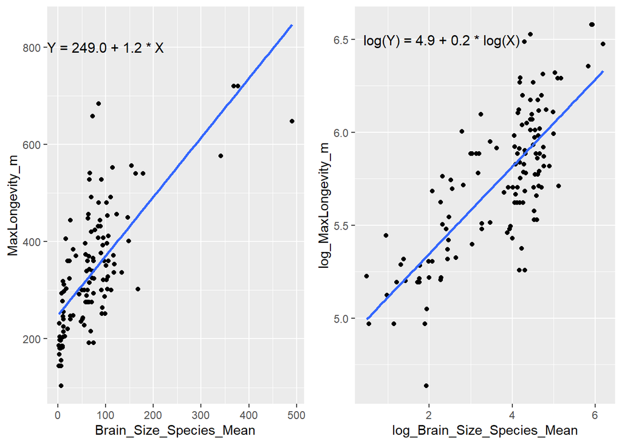

```r
p1 <- ggplot(d, aes(y = MaxLongevity_m, x = Brain_Size_Species_Mean)) +
  geom_point() +
  geom_smooth(method = "lm", formula = y ~ x, se = FALSE) +
  annotate("text", label = "Y = 249.0 + 1.2 * X", size = 4, x = 100, y = 800)

p2 <- ggplot(d, aes(y = log_MaxLongevity_m, x = log_Brain_Size_Species_Mean)) +
  geom_point() +
  geom_smooth(method = "lm", formula = y  ~ x, se = FALSE) +
  annotate("text", label = "log(Y) = 4.9 + 0.2 * log(X)", size = 4, x = 2.3, y = 6.5)

grid.arrange(p1, p2, nrow = 1)
```

## β1 does not equal 0 in either model (1.2 and 0.2) so H0 can be rejected in both cases.

## Calculating 90% confidence intervals.

```r
alpha = 0.1

(CIA <- tidy(a, conf.int = TRUE, conf.level = 1 - alpha))
```

```
## # A tibble: 2 x 7
##   term                  estimate std.error statistic  p.value conf.low conf.high
##   <chr>                    <dbl>     <dbl>     <dbl>    <dbl>    <dbl>     <dbl>
## 1 (Intercept)             249.      11.1        22.4 8.91e-46   231.      267.
## 2 Brain_Size_Species_M~     1.22     0.110      11.1 2.69e-20     1.04      1.40
```

```r
(CIB <- tidy(b, conf.int = TRUE, conf.level = 1 - alpha))
```

```
## # A tibble: 2 x 7
##   term                 estimate std.error statistic   p.value conf.low conf.high
##   <chr>                   <dbl>     <dbl>     <dbl>     <dbl>    <dbl>     <dbl>
## 1 (Intercept)             4.88     0.0691      70.6 3.32e-103    4.76      4.99
## 2 log_Brain_Size_Spec~    0.234    0.0178      13.1 2.17e- 25    0.205     0.264
```

## Adding Confidence and prediction interval bands to plot.

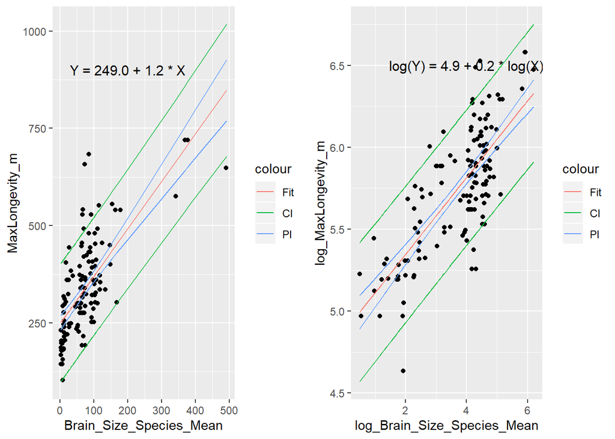

```r
cia <- predict(a, newdata = data.frame(Brain_Size_Species_Mean = d$Brain_Size_Species_Mean),
               interval = "confidence", level = 1 - alpha)
cia <- data.frame(cia)
cia <- cbind(d$Brain_Size_Species_Mean, cia)
names(cia) <- c("Brain_Size_Species_Mean", "c.fit", "c.lwr", "c.upr")
pia <- predict(a, newdata = data.frame(Brain_Size_Species_Mean = d$Brain_Size_Species_Mean),
               interval = "prediction", level = 1 - alpha)
pia <- data.frame(pia)
pia <- cbind(d$Brain_Size_Species_Mean, pia)
names(pia) <- c("Brain_Size_Species_Mean", "p.fit", "p.lwr", "p.upr")

cib <- predict(b, newdata = data.frame(log_Brain_Size_Species_Mean = d$log_Brain_Size_Species_Mean),
               interval = "confidence", leve = 1 - alpha)
cib <- data.frame(cib)
cib <- cbind(d$log_Brain_Size_Species_Mean, cib)
names(cib) <- c("log_Brain_Size_Species_Mean", "c.fit", "c.lwr", "c.upr")
pib <- predict(b, newdata = data.frame(log_Brain_Size_Species_Mean = d$log_Brain_Size_Species_Mean),
               interval = "prediction", level = 1 - alpha)
pib <- data.frame(pib)
pib <- cbind(d$log_Brain_Size_Species_Mean, pib)
names(pib) <- c("log_Brain_Size_Species_Mean", "p.fit", "p.lwr", "p.upr")


p1 <- ggplot(d, aes(y = MaxLongevity_m, x = Brain_Size_Species_Mean)) +
  geom_point() +
  annotate("text", label = "Y = 249.0 + 1.2 * X", size = 4, x = 200, y = 900) +
  geom_line(data = cia, aes(x = Brain_Size_Species_Mean, y = c.fit, color = "black")) +
  geom_line(data = cia, aes(x = Brain_Size_Species_Mean, y = c.lwr, color = "red")) +
  geom_line(data = cia, aes(x = Brain_Size_Species_Mean, y = c.upr, color = "red")) +
  geom_line(data = pia, aes(x = Brain_Size_Species_Mean, y = p.lwr, color = "purple")) +
  geom_line(data = pia, aes(x = Brain_Size_Species_Mean, y = p.upr, color = "purple")) +
  scale_color_hue(labels = c("Fit", "CI", "PI"))

p2 <- ggplot(d, aes(y = log_MaxLongevity_m, x = log_Brain_Size_Species_Mean)) +
  geom_point() +
    annotate("text", label = "log(Y) = 4.9 + 0.2 * log(X)", size = 4, x = 4, y = 6.5) +
  geom_line(data = cib, aes(x = log_Brain_Size_Species_Mean, y = c.fit, color = "black")) +
  geom_line(data = cib, aes(x = log_Brain_Size_Species_Mean, y = c.lwr, color = "red")) +
  geom_line(data = cib, aes(x = log_Brain_Size_Species_Mean, y = c.upr, color = "red")) +
  geom_line(data = pib, aes(x = log_Brain_Size_Species_Mean, y = p.lwr, color = "purple")) +
  geom_line(data = pib, aes(x = log_Brain_Size_Species_Mean, y = p.upr, color = "purple")) +
  scale_color_hue(labels = c("Fit", "CI", "PI"))

grid.arrange(p1, p2, nrow = 1)
```

## Point estimate and 90% prediction interval of longevity for a species whose brain weight is 750g.

## This estimate should not be trusted because the observed brain weight of the species is outside of the range of values within the model.

```r
cia_point <- predict(a,
               newdata = data.frame(Brain_Size_Species_Mean = 750),
               interval = "confidence", level = 1 - alpha
)
cia_point
```

```
##        fit      lwr      upr
## 1 1162.445 1037.634 1287.256
```

```r
pia_point <- predict(a,
                     newdata = data.frame(Brain_Size_Species_Mean = 750),
                     interval = "prediction", level = 1 - alpha
)
pia_point
```

```
##        fit      lwr      upr
## 1 1162.445 966.8151 1358.075
```

```r
cib_point <- predict(b,
                     newdata = data.frame(log_Brain_Size_Species_Mean = log(750)),
               interval = "confidence", level = 1 - alpha
)
exp(cib_point)
```

```
##        fit      lwr      upr
## 1 619.5778 563.9033 680.7491
```

```r
pib_point <- predict(b,
                     newdata = data.frame(log_Brain_Size_Species_Mean = log(750)),
                     interval = "confidence", level = 1 - alpha
)
exp(cib_point)
```

```
##        fit      lwr      upr
## 1 619.5778 563.9033 680.7491
```

## Looking at the two models, the log-log transformed model is a better fit for the data because the fit line has smaller residuals and the points are distributed more linearly.

# Challenge 2

## Running linear regression of log(HomeRange_km2) and log(Body_mass_female_mean)

```r
d <- d %>%
  mutate(log_HomeRange_km2 = log(HomeRange_km2),
         log_Body_mass_female_mean = log(Body_mass_female_mean)
  )

c <- lm(log_HomeRange_km2 ~ log_Body_mass_female_mean, data = d)
c
```

```
##
## Call:
## lm(formula = log_HomeRange_km2 ~ log_Body_mass_female_mean, data = d)
##
## Coefficients:
##               (Intercept)  log_Body_mass_female_mean
##                    -9.441                      1.036
```

## Bootstrap of 1000 samples from dataset

```r
e <- list()
slope <- vector()
intercept <- vector()
for (i in 1:1000) {
  e[[i]] <- sample_n(d, size = nrow(d), replace = TRUE)
  f <- lm(log_HomeRange_km2 ~ log_Body_mass_female_mean, data = e[[i]])
  slope[[i]] <- f$coefficients[2]
  intercept[[i]] <- f$coefficients[1]
}

new <- tibble(
  slope = slope,
  intercept = intercept)
```

## Histograms for β0 and β1

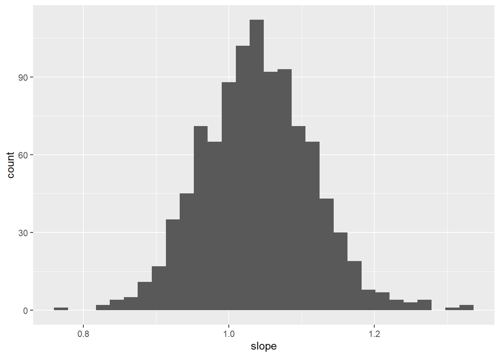

```r
ggplot(new, aes(x = slope)) +
  geom_histogram()
```

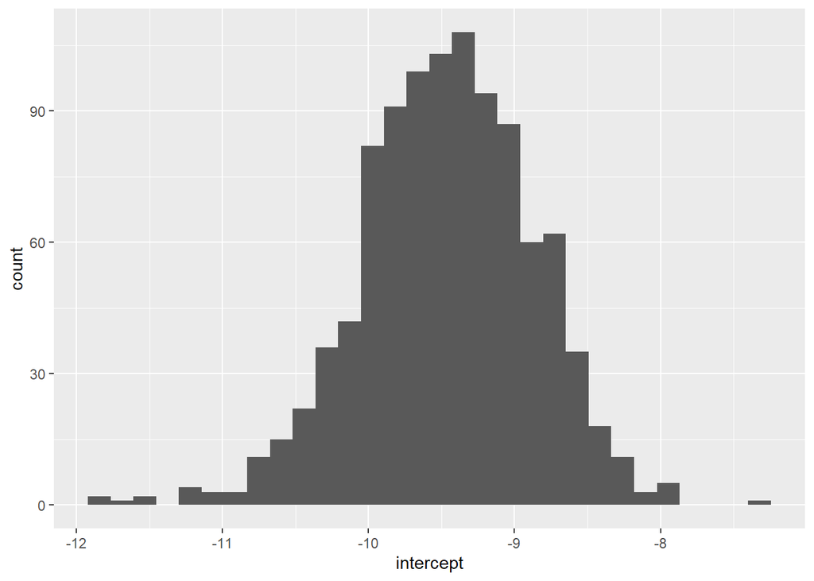

```r
ggplot(new, aes(x = intercept)) +
  geom_histogram()
```

## Estimates for SE and 95% for each β coefficient

```r
alpha <- 0.05
confidence_level <- 1 - alpha
p_lower <- alpha / 2
p_upper <- 1 - (alpha / 2)
degrees_of_freedom <- nrow(new) - 2
critical_value <- qt(p_upper, df = degrees_of_freedom)

bs_ci_slope <- new %>%
  summarize(
    estimate = mean(slope),
    std.error = sd(slope),
    lower = estimate - std.error * critical_value,
    upper = estimate + std.error * critical_value,
    perm.lower = quantile(slope, p_lower),
    perm.upper = quantile(slope, p_upper)
  )
bs_ci_slope
```

```
## # A tibble: 1 x 6
##   estimate std.error lower upper perm.lower perm.upper
##      <dbl>     <dbl> <dbl> <dbl>      <dbl>      <dbl>
## 1     1.04    0.0755 0.891  1.19      0.900       1.19
```

```r
bs_ci_intercept <- new %>%
  summarize(
    estimate = mean(intercept),
    std.error = sd(intercept),
    lower = estimate - std.error * critical_value,
    upper = estimate + std.error * critical_value,
    perm.lower = quantile(intercept, p_lower),
    perm.upper = quantile(intercept, p_upper)
  )
bs_ci_intercept
```

```
## # A tibble: 1 x 6
##   estimate std.error lower upper perm.lower perm.upper
##      <dbl>     <dbl> <dbl> <dbl>      <dbl>      <dbl>
## 1    -9.47     0.593 -10.6 -8.30      -10.7      -8.39
```

## The lm() function found that SE = 0.0848771 and CI = 0.8685707 - 1.2042923 for β1, and SE = 0.6729346 and CI = -10.7720889 - -8.1103738 for β0.

## The bootstrap method found that SE = 0.0755302 and CI = 0.8997333 - 1.1869582 for β1, and SE = 0.5932014 and CI = -10.6808192 - -8.390106 for β0

# Challenge 3

## Creating the function

```r
boot_lm <- function(d, model, conf.level = 0.95, reps = 1000) {
  d <- d %>% mutate(
      logHR = log(HomeRange_km2),
      logBM = log(Body_mass_female_mean),
      logDL = log(DayLength_km)
  )
  model <- as.formula(model)

  c <- lm(model, data = d)

  z <- list()
  slope <- vector()
  intercept <- vector()
  x <- for (i in 1:reps) {
    z[[i]] <- sample_n(d, size = nrow(d), replace = TRUE)
    e <- lm(model, data = z[[i]])
    slope[[i]] <- e$coefficients[2]
    intercept[[i]] <- e$coefficients[1]
  }

  new <- tibble(
    slope = slope,
    intercept = intercept)

  confidence_level <- conf.level
  alpha <- 1 - conf.level
  p_lower <- alpha / 2
  p_upper <- 1 - (alpha / 2)
  degrees_of_freedom <- nrow(new) - 2
  critical_value <- qt(p_upper, df = degrees_of_freedom)

  new <- new %>%
    summarize(
      model = "boot",
      beta1 = mean(slope),
      beta1.std.error = sd(slope),
      beta1.ci.lower = quantile(slope, p_lower),
      beta1.ci.upper = quantile(slope, p_upper),
      beta0 = mean(intercept),
      beta0.std.error = sd(intercept),
      beta0.ci.lower = quantile(intercept, p_lower),
      beta0.ci.upper = quantile(intercept, p_upper),

    )
  lm_model <- tibble(model = "lm()",
                     beta1 = c$coefficients[2],
                     beta1.std.error = tidy(c)$std.error[2],
                     beta1.ci.lower =  tidy(c, conf.int = TRUE, conf.level = conf.level)$conf.low[2],
                     beta1.ci.upper =  tidy(c, conf.int = TRUE, conf.level = conf.level)$conf.high[2],
                     beta0 = c$coefficients[1],
                     beta0.std.error = tidy(c)$std.error[1],
                     beta0.ci.lower = tidy(c, conf.int = TRUE, conf.level = conf.level)$conf.low[1],
                     beta0.ci.upper = tidy(c, conf.int = TRUE, conf.level = conf.level)$conf.high[1]
  )
  new <- rbind(lm_model, new)
  new
}
```

## Running the function on:

### log(HomeRange_km2) ~ log(Body_mass_female_mean)

### log(DayLength_km) ~ log(Body_mass_female_mean)

### log(HomeRange_km2) ~ log(Body_mass_female_mean) + MeanGroupSize

```r
boot_lm(d = d, model = "logHR ~ logBM")
```

```
## # A tibble: 2 x 9
##   model beta1 beta1.std.error beta1.ci.lower beta1.ci.upper beta0
##   <chr> <dbl>           <dbl>          <dbl>          <dbl> <dbl>
## 1 lm()   1.04          0.0849          0.869           1.20 -9.44
## 2 boot   1.04          0.0776          0.891           1.20 -9.47
## # ... with 3 more variables: beta0.std.error <dbl>, beta0.ci.lower <dbl>,
## #   beta0.ci.upper <dbl>
```

```r
boot_lm(d = d, model = "logDL ~ logBM")
```

```
## # A tibble: 2 x 9
##   model  beta1 beta1.std.error beta1.ci.lower beta1.ci.upper  beta0
##   <chr>  <dbl>           <dbl>          <dbl>          <dbl>  <dbl>
## 1 lm()  0.0389          0.0567        -0.0735          0.151 -0.143
## 2 boot  0.0379          0.0573        -0.0688          0.150 -0.135
## # ... with 3 more variables: beta0.std.error <dbl>, beta0.ci.lower <dbl>,
## #   beta0.ci.upper <dbl>
```

```r
boot_lm(d = d, model = "logHR ~ logBM + MeanGroupSize")
```

```
## # A tibble: 2 x 9
##   model beta1 beta1.std.error beta1.ci.lower beta1.ci.upper beta0
##   <chr> <dbl>           <dbl>          <dbl>          <dbl> <dbl>
## 1 lm()  0.850          0.0942          0.663           1.04 -8.66
## 2 boot  0.843          0.0811          0.682           1.00 -8.62
## # ... with 3 more variables: beta0.std.error <dbl>, beta0.ci.lower <dbl>,
## #   beta0.ci.upper <dbl>
```

#Extra Credit

##Running loop for 10-200 by 10 rep bootsrap

```r
a <- tibble()

for (i in seq(10, 200, by =10)) {
  r <- boot_lm(d = d, model = "logHR ~ logBM", reps = i)
  a <- rbind(a, c(i, r[[2]][[2]],r[[4]][[2]], r[[5]][[2]], r[[2]][[1]]))
}
names(a) <- c("reps", "beta1", "CI_low", "CI_high", "actual_beta1")
```

## Plotting the result!

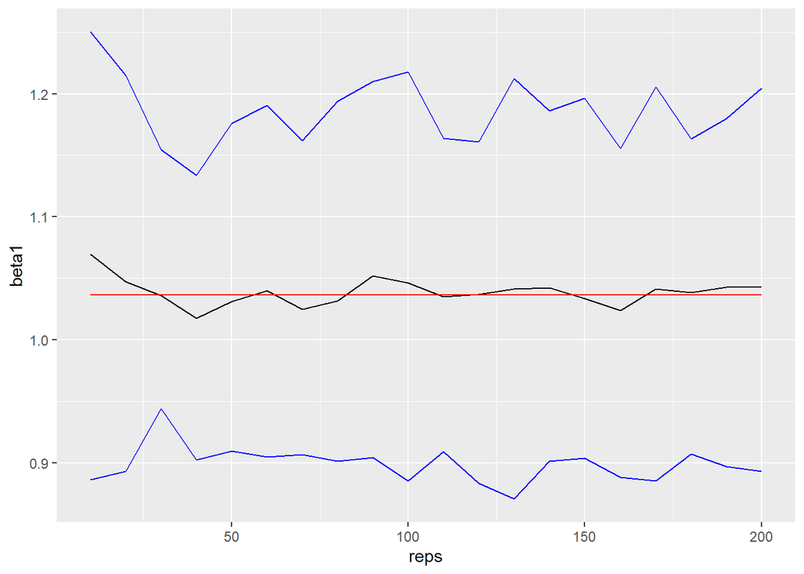

```r
ggplot(data = a, aes(x = reps)) +
  geom_line(data = a, aes(x = reps, y = beta1, color = "black"), color = "black") +
  geom_line(data = a, aes(x = reps, y = CI_low, color = "blue"), color = "blue") +
  geom_line(data = a, aes(x = reps, y = CI_high, color = "blue"), color = "blue") +
  geom_line(data = a, aes(x = reps, y = actual_beta1, color = "red"), color = "red")
```